# 11. 경쟁위험 생존분석

#### 경쟁위험 : 여러 종류의 사건 중 하나만 경험할 수 있는 경우, 이들 사건의 발생확률

- 경쟁위험 생존데이터는 콕스모형에 적합시킬 수 있고, 모수적 생존모형에 적합 시킬 수 있으며, 생존이 아닌 누적발생률을 사용하는 모형에 적합시킬 수 있음

### 11-1 경쟁위험의 예

#### 경쟁위험은 한 대상환자에서 한 가지 이상의 이벤트(실패)가 발생할 수 있지만, 그중 하나의 이벤트만 일어날 때 발생

- 어떤 환자는 폐암으로 사망하거나 심혈관질환으로 사망할 수 있으나, 두 가지 사망이 동시에 일어날 수 없다
- 암환자가 수술 후 병원감염으로 사망하거나, 병원감염이 일어나기 전 수술로 인해 사망할 수 있다
- 참전한 군인은 전투로 사망할 수도 있으나, 사고로 사망할 수 있다

#### 그러나, 사망사건이 아닌 경우에는, 추적기간 중 이벤트가 여러번 발생할 수도 있다 (경쟁위험의 재발사건)

#### 경쟁위험 모형분석의 목적 : 관련있는 예측변수들과 가능한 몇 가지 경쟁위험의 발생률 또는 생존율의 관계를 평가. 또한, 관련 있는 예측변수들의 영향을 통제하고 경쟁위험들의 위험비를 비교

- 폐암과 심혈관질환의 경쟁위험 연구
  - 심혈관질환으로 인한 사망가능성을 열어놓은 채, 어떤 물질에 노출된 환자의 폐암으로 인한 사망률과 노출되지 않은 환자의 폐암으로 인한 사망률의 차이가 있는지 연구
  - 다른 예측변수들의 영향을 통제한 상태에서 폐암으로 인한 사망률과 심혈관질환으로 사망률을 비교
- 암환자의 수술 후 사망과 병원내감염에 대한 경쟁위험
  - 감연관리에 관심이 있는 연구자에게는 원내감염이 관심사
  - **수술후 사망은 원내감염으로 인한 사망의 경쟁위험**
- 참전군인의 사망
  - 전투로 인한 사망과 사고로 인한 사망은 경쟁위험
  - 연구의 주된 관심사는 노출된 군과 노출되지 않은 군의 전투로 인한 사망의 위험비
  - 하지만, 부대 전체가 시간 t에 헬리콥터를 타고 전투지역으로 이동 중 사고로 모두 사망했을경우, 시간 t까지 전투로 인한 사망은 없었으므로, 전투에 의한 생존가능성은 1
  - 하지만 연구자가 관심있는 결과를 **전투 혹은 사고로 인한 사망**으로 할 경우, 시간 t이후 이벤트 없는 생존확률 (event-free survival rate)은 0

### 11-2 Byar 데이터

- 전립선암 환자를 대상으로 위약 또는 3가지 용량의 에스트로젠을 사용한 무작위 임상시험 데이터
- `status2` : 생존의 경우 0 / 전립선으로 인한 사망은 1 / 심혈관질환으로 인한 사망은 2 / 기타원인의 사망은 3
- 주요 위험인자는 나이, 모뭄게, 수행상태, 심혈관질환의 과거력, 혈중 헤모글로빈 농도, 원발성 종괴의 크기, 병기, 조직학적 지표 등
- **경쟁위험이 있는 상태에서 이들 위험인자의 영향을 보정한 후 치료의 효과를 평가하는 것이 1차적 목표**
- **임상적인 관점에서 전립선암으로 인한 사망과 심혈관질환으로 인한 사망, 기타 원인에 의한 사망은 서로 독립적**

### 11-3 각각의 경쟁위험을 분리된 모형에 적합 (가장 전형적인 방법)

- 다른 경쟁위험들은 중도절단된 것으로 간주
  - 한 가지 실패 유형만이 일차적 관심사라면 다른 경쟁위험들은 중도절단된 것으로 처리, 실패 유형에 대한 위험비를 추정

### $h_c (t) = \lim_{\Delta t -> 0 } {{P(t \leq T_c < t + \Delta t | T_c \geq t)}\over{\Delta t}}$

- $T_c$ : 이벤트 c의 time-to-failure, c는 경쟁위험의 개수만큼 1, 2, ..., C까지 존재
- $h_c(t)$ : 시간 t까지 이벤트 c가 일어나지 않았다는 조건하에 시간 t에서의 순간적인 실패확률

#### 콕스모형에 적합시키기 위해 p개의 예측변수 $X = X_1, X_2, ..., X_p$를 고려한 원인별 위험함수

### $h_c(t, X) = h_{0c}(t) \times exp(\sum^p_{i=1} \beta_{ic} X_i),\;\;\;\; c= 1, ..., C$

#### 경쟁위험 중 status = 1에 대한 원인별 위험함수로 만든 콕스모형

- `Rx`에 대한 회귀계수 = -0.423, 위험비 = 0.655

```r
library(survival)
library(tidyverse)
library(howto)
library(autoReg)
library(officer)
```

```r
fit1 = coxph(Surv(dtime, status2 ==1) ~ Rx + Age + Wt + PF + Hx + Hb + SZ + SG, Byar)
gaze(fit1)
```

A autoReg: 8 × 8

|  | <chr> | coef <chr> | se(coef) <chr> | z <chr> | Pr(>\|z\|) <chr> | HR <chr> | lower <chr> | upper <chr> |
| --- | --- | --- | --- | --- | --- | --- | --- | --- |
| Rx | Rx | -0.423 | 0.202 | -2.094 | .036 | 0.655 | 0.441 | 0.973 |
| Age | Age | -0.120 | 0.160 | -0.750 | .453 | 0.887 | 0.648 | 1.214 |
| Wt | Wt | 0.129 | 0.151 | 0.856 | .392 | 1.138 | 0.847 | 1.530 |
| PF | PF | 0.400 | 0.273 | 1.463 | .143 | 1.492 | 0.873 | 2.551 |
| Hx | Hx | -0.099 | 0.200 | -0.495 | .621 | 0.906 | 0.612 | 1.341 |
| Hb | Hb | 0.407 | 0.196 | 2.076 | .038 | 1.502 | 1.023 | 2.206 |
| SZ | SZ | 1.172 | 0.216 | 5.430 | <.001 | 3.230 | 2.115 | 4.931 |
| SG | SG | 2.181 | 0.283 | 7.709 | <.001 | 8.854 | 5.086 | 15.415 |

#### 경쟁위험 중 status = 2에 대한 원인별 위험하수로 만든 콕스모형

- `Rx`에 대한 회귀계수는 통계적으로 유의하지 않음

```r
fit2 = coxph(Surv(dtime, status2 == 2) ~ Rx + Age + Wt + PF + Hx + Hb + SZ + SG, Byar)
gaze(fit2)
```

A autoReg: 8 × 8

|  | <chr> | coef <chr> | se(coef) <chr> | z <chr> | Pr(>\|z\|) <chr> | HR <chr> | lower <chr> | upper <chr> |
| --- | --- | --- | --- | --- | --- | --- | --- | --- |
| Rx | Rx | 0.060 | 0.198 | 0.301 | .763 | 1.062 | 0.720 | 1.566 |
| Age | Age | 0.346 | 0.135 | 2.557 | .011 | 1.413 | 1.084 | 1.841 |
| Wt | Wt | 0.063 | 0.150 | 0.423 | .672 | 1.065 | 0.795 | 1.428 |
| PF | PF | 0.462 | 0.271 | 1.707 | .088 | 1.588 | 0.934 | 2.699 |
| Hx | Hx | 1.104 | 0.186 | 5.950 | <.001 | 3.017 | 2.097 | 4.341 |
| Hb | Hb | 0.026 | 0.204 | 0.126 | .900 | 1.026 | 0.688 | 1.530 |
| SZ | SZ | -0.155 | 0.361 | -0.429 | .668 | 0.857 | 0.422 | 1.738 |
| SG | SG | -0.041 | 0.185 | -0.224 | .823 | 0.959 | 0.667 | 1.379 |

- `Rx`에 대한 회귀계수는 통계적으로 유의하지 않음

```r
fit3 = coxph(Surv(dtime, status2 == 3) ~ Rx + Age + Wt + PF + Hx + Hb + SZ + SG, Byar)
gaze(fit3)
```

A autoReg: 8 × 8

|  | <chr> | coef <chr> | se(coef) <chr> | z <chr> | Pr(>\|z\|) <chr> | HR <chr> | lower <chr> | upper <chr> |
| --- | --- | --- | --- | --- | --- | --- | --- | --- |
| Rx | Rx | -0.064 | 0.256 | -0.250 | .803 | 0.938 | 0.568 | 1.548 |
| Age | Age | 0.669 | 0.171 | 3.915 | <.001 | 1.952 | 1.397 | 2.729 |
| Wt | Wt | 0.572 | 0.194 | 2.954 | .003 | 1.771 | 1.212 | 2.589 |
| PF | PF | 0.128 | 0.409 | 0.314 | .754 | 1.137 | 0.510 | 2.535 |
| Hx | Hx | 0.054 | 0.240 | 0.226 | .821 | 1.056 | 0.660 | 1.689 |
| Hb | Hb | 0.486 | 0.235 | 2.070 | .038 | 1.626 | 1.026 | 2.578 |
| SZ | SZ | 0.717 | 0.373 | 1.924 | .054 | 2.049 | 0.987 | 4.254 |
| SG | SG | -0.771 | 0.262 | -2.939 | .003 | 0.462 | 0.276 | 0.773 |

### 11-4 독립성 가정

#### 중도절단에서 중요한 가정 : '중도절단은 독립적'

### $h(t | G, Ce) = h(t|G,NCe)$

($G$ = 시간 t에서 임의의 서브그룹에 속해 있는 대상 / $h(t|G, Ce)$ = 서브그룹 G의 중도절단된 대상들의 위험)

#### **시간 t에서 임의의 서브그룹 G에 속한 중도절단 대상의 위험은, 중도절단되지 않고 남아 있는 대상들의 위험과 같다는 가정**

- 독립적이지 않은 중도절단은 생존분석에서 치우친 결과(biased result)를 생성
- **중도절단된 사람들이 남아 있는 사람들에 비해 실패할 가능성이 더 많다면, 임의의 시간 t에서 생존확률의 참값보다 추정된 생존확률이 과대추정되어 편향된 결과를 만들 수 있음**

#### 그렇다면 중도절단의 독립성 가정이 필요하다면, 독립성 가정이 만족되는지 어떻게 결정할 것인가

- 명시적으로 증명할 수 없음

#### 독립성 가정이 만족되지 않을 경우 어떻게 분석을 진행할 것인가?

- 첫 번째 대안 : 데이터 분석에 의존하지 않고 다른 근거에 의해 독립성 가족을 만족한다고 판단 (임상적, 생물학적 등)
- 두 번째 대안 : 경쟁위험들에 공통되는 위험요인들을 고려하여, 생존모형에 포함
- **세 번째 대안 : 민감도분석**
  - 민감도분석은 독립성 가정을 만족하는지 명시적으로 증명할 수는 없지만, **독립성 가정에 위배되는 '최악의 사례'들로부터 넓은 추정구간을 결정하고, 그 결과가 독립성 가정하에 분석한 결과와 의미있게 다르지 않다면, 독립성 가정하에 얻은 결과에 약간의 편향만 존재한다고 결론 가능**

#### 독립성 가정하에 구한 모형과, 최악의 사례하의 모형간의 위험비를 비교

- 암으로 인한 사망을 주 관심사건으로 원인별 위험모형을 생성
  - 2가지의 '최악의 사례' 정의
  1. 기타원인에 의한 사망을 암으로 인한 사망으로 처리
  2. 기타원인에 의한 사망을 중도절단으로 처리하되, 그 데이터에서 가장 오래 기록된 생존시간까지 생존한 것으로 처리
1. 기타원인에 의한 사망을 암으로 인한 사망으로 처리한 경우

```r
Byar2 = Byar %>% mutate(status2 = ifelse(status2 > 1, 1, status2)) # 기타원인으로 인한 사망을 암으로 인한 사망으로 처리
fit4 = coxph(Surv(dtime, status2 == 1) ~ Rx + Age + Wt + PF + Hx + Hb + SZ + SG, Byar2)
gaze(fit4)
```

A autoReg: 8 × 8

|  | <chr> | coef <chr> | se(coef) <chr> | z <chr> | Pr(>\|z\|) <chr> | HR <chr> | lower <chr> | upper <chr> |
| --- | --- | --- | --- | --- | --- | --- | --- | --- |
| Rx | Rx | -0.131 | 0.123 | -1.068 | .286 | 0.877 | 0.689 | 1.116 |
| Age | Age | 0.281 | 0.087 | 3.235 | .001 | 1.325 | 1.117 | 1.571 |
| Wt | Wt | 0.202 | 0.093 | 2.174 | .030 | 1.224 | 1.020 | 1.467 |
| PF | PF | 0.406 | 0.171 | 2.375 | .018 | 1.501 | 1.074 | 2.100 |
| Hx | Hx | 0.458 | 0.112 | 4.093 | <.001 | 1.581 | 1.270 | 1.969 |
| Hb | Hb | 0.293 | 0.120 | 2.442 | .015 | 1.340 | 1.059 | 1.695 |
| SZ | SZ | 0.667 | 0.159 | 4.193 | <.001 | 1.949 | 1.427 | 2.663 |
| SG | SG | 0.406 | 0.116 | 3.509 | <.001 | 1.500 | 1.196 | 1.882 |

1. 기타원인에 의한 사망을 중도절단으로 처리하고, 가장 오래 기록된 생존시간까지 생존한 것으로 처리한 경우

```r
Byar3 = Byar %>% mutate(dtime = ifelse(status2 > 1, max(dtime), dtime),
                        status2 = ifelse(status2 > 1, 0, status2))
fit5 = coxph(Surv(dtime, status2 == 1) ~ Rx + Age + Wt + PF + Hx + Hb + SZ + SG, Byar3)
gaze(fit5)
```

A autoReg: 8 × 8

|  | <chr> | coef <chr> | se(coef) <chr> | z <chr> | Pr(>\|z\|) <chr> | HR <chr> | lower <chr> | upper <chr> |
| --- | --- | --- | --- | --- | --- | --- | --- | --- |
| Rx | Rx | -0.190 | 0.198 | -0.957 | .339 | 0.827 | 0.560 | 1.220 |
| Age | Age | -0.207 | 0.155 | -1.332 | .183 | 0.813 | 0.599 | 1.102 |
| Wt | Wt | 0.017 | 0.151 | 0.113 | .910 | 1.017 | 0.757 | 1.368 |
| PF | PF | 0.302 | 0.260 | 1.161 | .246 | 1.353 | 0.812 | 2.254 |
| Hx | Hx | -0.273 | 0.198 | -1.379 | .168 | 0.761 | 0.517 | 1.122 |
| Hb | Hb | 0.302 | 0.185 | 1.635 | .102 | 1.352 | 0.942 | 1.942 |
| SZ | SZ | 0.805 | 0.205 | 3.916 | <.001 | 2.236 | 1.495 | 3.344 |
| SG | SG | 2.143 | 0.282 | 7.614 | <.001 | 8.529 | 4.912 | 14.809 |

```r
bind_rows(gaze(fit1)[1, ], gaze(fit4)[1, ], gaze(fit5)[1, ]) -> bind
rownames(bind) <- c("fit1 Independent", "fit4 WC1", "fit5 WC2")
bind
```

A autoReg: 3 × 8

|  | <chr> | coef <chr> | se(coef) <chr> | z <chr> | Pr(>\|z\|) <chr> | HR <chr> | lower <chr> | upper <chr> |
| --- | --- | --- | --- | --- | --- | --- | --- | --- |
| fit1 Independent | Rx | -0.423 | 0.202 | -2.094 | .036 | 0.655 | 0.441 | 0.973 |
| fit4 WC1 | Rx | -0.131 | 0.123 | -1.068 | .286 | 0.877 | 0.689 | 1.116 |
| fit5 WC2 | Rx | -0.190 | 0.198 | -0.957 | .339 | 0.827 | 0.560 | 1.220 |

#### 하지만, 민감도분석 결과로 독립성 가정을 만족하는지 증명할 수 없으며, 독립성 가정이 위배되었을 때 위험비 및 z통계량의 편향되지 않은 추정치를 얻을 수는 없음

#### 결론적으로, 민감도분석은 독립성 가정을 평가하는 몇 가지 대안 중 하나이며, 독립성 가정이 위배되었을 때 분석결과가 얼마나 편향될 수 있는지 평가할 수 있게 해줌

#### 전형적인 생존분석 방법에서는 독립성 가정을 만족한다고 가정하고 분석을 진행

### 11-5 누적발생률함수

- 이전 장의 KM생존곡선은 한 종류의 실패(이벤트)만 있는 상황을 가정
- **경쟁위험이 있을 때 KM생존곡선은 위험이 하나일 때 처럼 유의한 결과를 제공하지 못함**

#### 예1 : 암환자 100명을 5개월간 추적하고, 99명의 환자가 3개월째에 심혈관질환으로 사망하였고, 마은 1명의 환자는 암으로 사망(심혈관질환은 중도절단으로 간주)

| Months | Died | Cause |
| --- | --- | --- |
| 3 | 99 | 심혈관질환 |
| 5 | 1 | 암 |

- $S(t_f)$ : 각 실패시간의 원인별 KM생존율
  - 5개월째 위험대상 수는 1명, 이 환자가 5개월째에 이벤트가 발생했으므로, 5개월째의 KM 생존율
  - **$KM_{Ca}:S_{Ca}(t = 5) = S(t = 4) \times Pr(T > 5 | T\geq 5) = 1 \times 0 = 0$**
  - 5개월째에 암으로 인한 원인별 사망률 : $1 - S_{Ca} = 1$, 99명의 대상환자가 암이 아닌 심혈관질환으로 사망하였으므로, 처음 100명의 대상환자 중 암으로 사망한 비율은 0.01

| $t_f$ | $n_f$ | $m_f$ | $q_f$ | $S(t_f)$ |
| --- | --- | --- | --- | --- |
| $0$ | $100$ | $0$ | $0$ | $1$ |
| $3$ | $100$ | $0$ | $99$ | $1$ |
| $5$ | $1$ | $1$ |  | $0$ |

#### 예2 : 3월째에 사망한 99명의 대상환자들이 3개월째 심혈관질환으로 사망하지 않았다면, 모두 5개월째에 암으로 사망하였을 것이라고 가정

- 5개월째의 KM생존율은 원래 데이터와 마찬가지로 0
  - 5개월 생존율이 0으로 같은 이유는 KM방법은 중도절단이 독립적이라고 가정(independent censoring)

| $t_f$ | $n_f$ | $m_f$ | $q_f$ | $S(t_f)$ |
| --- | --- | --- | --- | --- |
| $0$ | $100$ | $0$ | $0$ | $1$ |
| $3$ | $100$ | $0$ | $0$ | $1$ |
| $5$ | $100$ | $100$ | $0$ | $0$ |

#### 예3 : 3개월째에 사망한 99명의 환자가 사망하지 않고 5개월까지 생존해 있다가 연구가 종료

- 1 - 0.99 = 0.01은 전체 대상환자 중 심혈관질환으로 사망 여부를 고려하지 않을 경우 암으로 인하여 사망하는 환자들의 비율로 주변확률 (marginal probability)

| $t_f$ | $n_f$ | $m_f$ | $q_f$ | $S(t_f)$ |
| --- | --- | --- | --- | --- |
| $0$ | $100$ | $0$ | $0$ | $1$ |
| $3$ | $100$ | $0$ | $0$ | $1$ |
| $5$ | $100$ | $1$ | $99$ | $0.99$ |

#### 1(예2)과 0.01(예3)중 어느 것이 더 좋은 정보를 제공하는 추정치인가?

#### => 경쟁위험을 어떻게 인식할 것인가?

#### 누적발생률함수 (cumulative incidence function)

- 경쟁위험 데이터에서 KM생존곡선의 대안 중 하나로 앞 절에서 소개한 주변확률을 사용
  - 경쟁위험이 하나인 경우 $CIF = 1 - KM$
  - 경쟁위험이 2개 이상인 경우 CIF는 원인별 위험함수에서 추정
- 경쟁위험이 있는 경우 위험의 주변확률로 경쟁위험이 독립적이라는 가정이 필요없음

**누적발생률곡선 계산**

1. 관심 있는 이벤트를 c라고 할 때, 정렬된 실패시간 $t_f$에서의 위험
- $\hat{h_c}(t_f) = m_{cf} / n_f$

($m_f$는 시간 $t_f$에서 발생한 이벤트 c의 개수이며, $n_f$는 $t_f$에서의 위험대상 수)

1. 실패시간 $t_f$에서 실패가 발생하려면 대상환자가 실패가 일어나기 전 시간까지 살아 있어야 하므로 $S(t_{f-1})$을 추정. $S(t_{f-1})$은 바로 전의 실패시간 $t_{f-1}$에서 경쟁위험이 모두 없는 총 생존확률
2. 시간 $t_f$에서의 이벤트 c의 실패발생률 $(\hat{I_c}(t_f))$을 추정
- $\hat{I_c}(t_f) = \hat{S}(t_{f-1}) \times \hat{h_c}(t_f)$
1. **시간 $t_f$에서의 이벤트 c의 누적발생률($CIF_c$)은 실패시간 $t_1$부터 $t_f$까지의 실패발생률의 누적 합계**
- $CIF_c(t_f) = \sum^f_{f' = 1}\hat{I_c}(t_{f'}) = \sum^f_{f' = 1} \hat{S}(t_{f' - 1})\times \hat{h_c}(t_{f'})$

#### 경쟁위험이 없는 경우 $CIF = 1 - KM$이지만, 경쟁위험이 있는 경우에는 $CIF_c(t_f) \neq 1 - KM_c$

- **$1-KM_c$는 원인별 생존함수 $S_c(t)$를 계산하는데 쓰임** (경쟁위험으로 인한 실패를 중도절단으로 처리, **중도절단법(censored method)**)

#### $1 - KM_c = \sum^f_{f' = 1}\hat{S_c}(t_{f' - 1} \times \hat{h_c}(t_{f'}))$

#### 누적발생률함수 계산

- `status` : 암에 의해 사망 = 1 / 다른원인에 의해 사망(경쟁위험) = 2 / 생존 = 0

#### `data2CIC()` : 누적발생률 계산

```r
time = c(0.7, 3, 4.9, 6, 6, 6.9, 10, 10.8, 17.1, 20.3, 1.5, 2.8, 3.8, 4.7, 7, 10, 10, 11.2, 3.2, 7.6, 10, 11, 15, 24.4)
status = c(rep(1, 10), rep(2, 8), rep(8, 6))
df = data.frame(time, status)
```

```r
library(flextable)
library(ftExtra)
```

```r
result = data2CIC(df, cause = 1, add.CPC = F)
result
```

A data.frame: 21 × 7

| t <dbl> | n <int> | m <int> | h <dbl> | S <dbl> | I <dbl> | CIC1 <dbl> |
| --- | --- | --- | --- | --- | --- | --- |
| 0.0 | 24 | 0 | 0.000 | NA | 0.000 | 0.000 |
| 0.7 | 24 | 1 | 0.042 | 1.000 | 0.042 | 0.042 |
| 1.5 | 23 | 0 | 0.000 | 0.958 | 0.000 | 0.042 |
| 2.8 | 22 | 0 | 0.000 | 0.917 | 0.000 | 0.042 |
| 3.0 | 21 | 1 | 0.048 | 0.875 | 0.042 | 0.083 |
| 3.2 | 20 | 0 | 0.000 | 0.833 | 0.000 | 0.083 |
| 3.8 | 19 | 0 | 0.000 | 0.792 | 0.000 | 0.083 |
| 4.7 | 18 | 0 | 0.000 | 0.750 | 0.000 | 0.083 |
| 4.9 | 17 | 1 | 0.059 | 0.708 | 0.042 | 0.125 |
| 6.0 | 16 | 2 | 0.125 | 0.667 | 0.083 | 0.208 |
| 6.9 | 14 | 1 | 0.071 | 0.583 | 0.042 | 0.250 |
| 7.0 | 13 | 0 | 0.000 | 0.542 | 0.000 | 0.250 |
| 7.6 | 12 | 0 | 0.000 | 0.500 | 0.000 | 0.250 |
| 10.0 | 11 | 1 | 0.091 | 0.458 | 0.042 | 0.292 |
| 10.8 | 7 | 1 | 0.143 | 0.292 | 0.042 | 0.333 |
| 11.0 | 6 | 0 | 0.000 | 0.250 | 0.000 | 0.333 |
| 11.2 | 5 | 0 | 0.000 | 0.208 | 0.000 | 0.333 |
| 15.0 | 4 | 0 | 0.000 | 0.167 | 0.000 | 0.333 |
| 17.1 | 3 | 1 | 0.333 | 0.125 | 0.042 | 0.375 |
| 20.3 | 2 | 1 | 0.500 | 0.083 | 0.042 | 0.417 |
| 24.4 | 1 | 0 | 0.000 | 0.042 | 0.000 | 0.417 |

#### $CIF$(검은선)와 $1-KM$곡선(빨간선)

- CIF는 KM 생존함수와는 달리 승산한계법을 사용하지 않는 주변확률로 경쟁위험의 독립성 가정을 필요로 하지 않음
- CIF를 사용하기 위ㅣ해서는 각각의 경쟁위험의 합이 전체위험과 같아야 함 => **경쟁위험이 상호배타적이고 재발하지 않는 경우 이러한 가정이 성립**

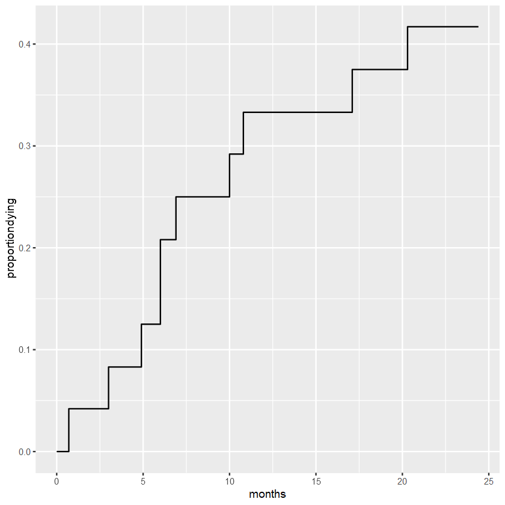

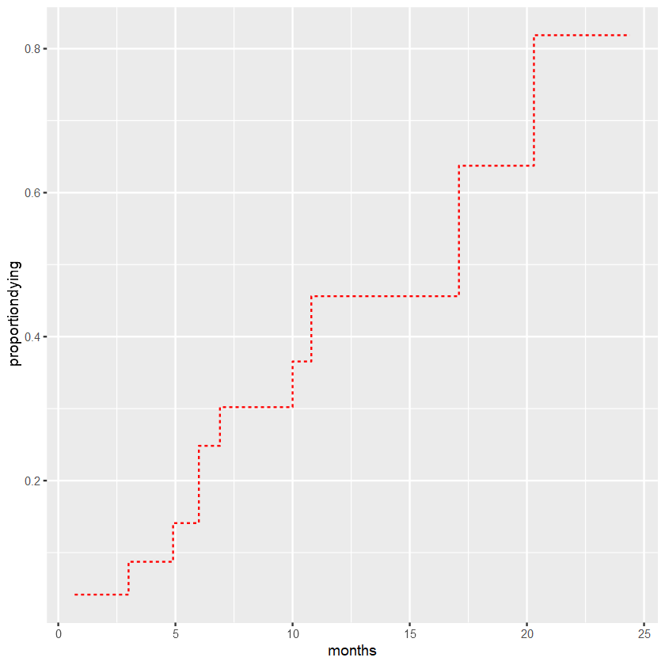

```r
fit = survfit(Surv(time, status == 1)~ 1, df)
df1 = data.frame(x = fit$time, y = 1 - fit$surv)

ggplot(result, aes(t, CIC1)) + geom_step() +
    labs(x = "months", y = "proportiondying")

ggplot(df1, aes(x, y)) + geom_step(lty = 2, color = "red") +
    labs(x = "months", y = "proportiondying")
```

#### 공변량이 있는 경우

- **공변량이 없는 경우 CIF를 계산할 때 경쟁위험의 독립성 가정이 필요 없지만 공변량의 효과를 고려하기 위해 중간 단계로 콕스모형을 사용하는 경우에는 경쟁위험의 독립성 가정이 필요**

#### Fine & Gray CIF모형

- **콕스비례위험모형과 유사하지만, CIF에서 파생된 sub-distribution 위험함수를 사용**
- **표준적인 콕스비례위험모형과 같이 해석**

#### 경쟁위험 c에 대한 sub-distribution 위험함수 ($h_{c, CIF}(t)$)는 다음과 같이 정의

- $h_{c, CIF}(t) = lim_{\Delta t = 0} {{pr(t < T_c < t + \Delta t | B)}\over{\Delta t}}$

  ($Where\;B\;=\;T_c > t\;or\;T_{c'},\;c' \neq c$) #
- 즉, B는 시간 t 이후에 경쟁위험 c가 발생하거나 ($T_c > t$)시간 t이전에 c가 아닌 다른 경쟁위험으로 인해 실패한 경우 $(T_{c'}\leq t, c' \neq c)$

#### $h_{c, CIF}(t) = {{\delta \;CIF_c(t)\;/ \;\delta t}\over{1 - CIF_c (t)}}$

#### 경쟁위험이 없는 경우와 경쟁위험이 있는 경우의 유사성

- $CIF_c(t)$는 다른 경쟁위험으로 인한 실패를 중도절단이 아니라, 실패로 간주하여 총 생존 $S(t)$를 사용

| $Competing\;Risks$ | $No\;Competing\;Risks$ |
| --- | --- |
| $h_{c, CIF}(t)$ | $h(t)$ |
| $\delta CIF_c(t)\;/\;\delta t$ | $f(t) = \delta F(t)\;/\;\delta t\;\;\;where\;\;\;F(t)=Pr(T \leq t)$ |
| $1-CIF_c(t)$ | $S(t) = 1- F(t)$ |

#### Fine & Gray CIF모형에서 시간 t에서의 경쟁위험 c의 위험함수 $h_{c, CIF}(t)$

#### $h_{c, CIF}(t) = h_{0c, CIF}\times exp(\sum^p_{i=1} \gamma_i X_i)$

#### 콕스비례위험모형의 위험함수 $h(t)$ 대신 subdistribution 위험함수 $h_{c, CIF}(t)$를 사용한 점을 제외하고는 콕스모형과 유사

#### $HR_{c, CIF}(X^*, X) = exp[\;\sum^p_{i=1}\gamma_i (X^*_i - X_i)\;]$

- 콕스비례위험모형의 비례위험 **$HR_{CoxPH}(X^*, X) = exp[\;\sum^p_{i=1} \beta_i (X^*_i - X_i)]$**의 $\beta$가 $\gamma$로 바뀐 것을 제외하면 동일
- FIne & Gray CIF모형에서도 시간의존공변량 등 비례위험 가정을 만족하지 않는 변수에 대해 확장하는 것이 가능

#### `crrFormula()` : Fine & Gray CIF 모형 적합

- 암에 의한 사망을 관심있는 이벤트로 하고 심혈관질환에 의한 사망과 다른 원인에 의한 사망을 중도절단 처리한 후 Fine & Gray CIF모형에 적합

```r
model = crrFormula(dtime + statusCancer ~ Rx + Age + Wt + PF + Hx + Hb + SZ + SG, data = Byar)
```

```
19 cases omitted due to missing values
```

```r
model
```

```
── crr() ───────────────────────────────────────────────────────────────────────────────────────────────────────────────

• Call survival::Surv(dtime, statusCancer) ~ Rx + Age + Wt + PF + Hx +  and  Hb + SZ + SG

• Failure type of interest "1"
```

```
Variable   Coef     SE      HR     95% CI       p-value
Rx         -0.421   0.205   0.66   0.44, 0.98   0.040
Age        -0.119   0.159   0.89   0.65, 1.21   0.46
Wt         0.126    0.154   1.13   0.84, 1.54   0.42
PF         0.393    0.283   1.48   0.85, 2.58   0.16
Hx         -0.097   0.202   0.91   0.61, 1.35   0.63
Hb         0.400    0.216   1.49   0.98, 2.28   0.064
SZ         1.16     0.203   3.20   2.15, 4.76   <0.001
SG         2.18     0.278   8.81   5.11, 15.2   <0.001
```

#### 표준 콕스경쟁위험모형으로 적합시킨 모형과 비교

- 거의 동일한 결과

```r
modelCox = coxph(Surv(dtime, statusCancer) ~ Rx + Age + Wt + PF + Hx + Hb + SZ + SG, Byar)
```

```r
autoReg(modelCox) %>% addFitSummary(model, statsname = "HR(CIF)")
```

A autoReg: 8 × 6

| name <chr> | desc <chr> | stats <chr> | id <chr> | HR (multivariable) <chr> | HR(CIF) <chr> |
| --- | --- | --- | --- | --- | --- |
| Rx | Mean ± SD | 0.7 ± 0.4 | Rx | 0.66 (0.44-0.97, p=.036) | 0.66 (0.44-0.98, p=.040) |
| Age | Mean ± SD | 0.4 ± 0.6 | Age | 0.89 (0.65-1.21, p=.453) | 0.89 (0.65-1.21, p=.460) |
| Wt | Mean ± SD | 0.6 ± 0.6 | Wt | 1.14 (0.85-1.53, p=.392) | 1.13 (0.84-1.54, p=.420) |
| PF | Mean ± SD | 0.1 ± 0.3 | PF | 1.49 (0.87-2.55, p=.143) | 1.48 (0.85-2.58, p=.160) |
| History of Cardiovascular Disease | Mean ± SD | 0.4 ± 0.5 | Hx | 0.91 (0.61-1.34, p=.621) | 0.91 (0.61-1.35, p=.630) |
| Hb | Mean ± SD | 0.2 ± 0.5 | Hb | 1.50 (1.02-2.21, p=.038) | 1.49 (0.98-2.28, p=.064) |
| SZ | Mean ± SD | 0.1 ± 0.3 | SZ | 3.23 (2.12-4.93, p<.001) | 3.20 (2.15-4.76, p<.001) |
| SG | Mean ± SD | 0.5 ± 0.5 | SG | 8.85 (5.09-15.42, p<.001) | 8.81 (5.11-15.19, p<.001) |

#### Gray 검정 : 2개 이상의 CIF곡선을 비교하는 통계적 검정

- 로그순위검정과 유사한 검정

#### `ggcmprsk()` : 누적발생률 비교

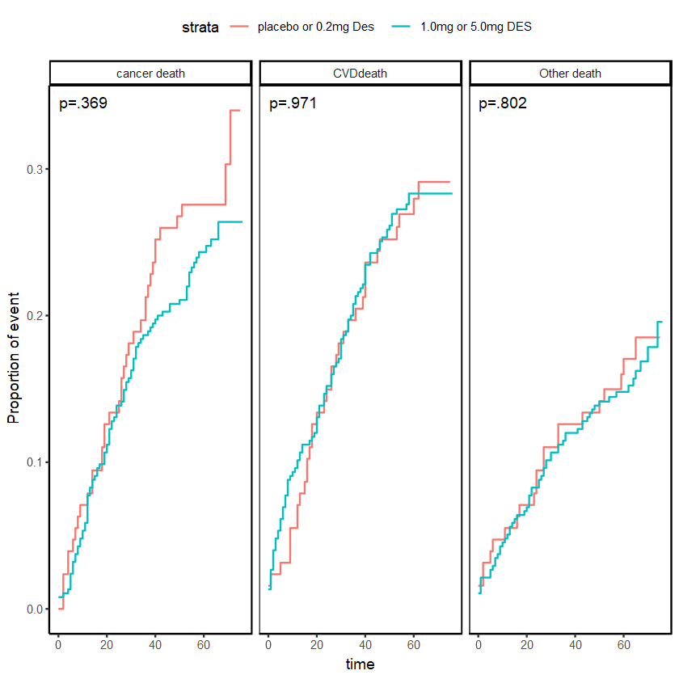

```r
ggcmprsk(dtime + status2 ~ Rx, Byar,
         id = c("alive", "cancer death", "CVDdeath", "Other death"),
         strata = c("placebo or 0.2mg Des", "1.0mg or 5.0mg DES"))
```

### 11-6 누적조건부확률함수 (cumulative conditional probability function, CPF)

- $CPF_c$ : 시간 t까지 다른 경쟁위험들을 경험하지 못한 대상에서 이벤트 c를 경험할 확률
  - $T_C$ : 이벤트 c가 일어날 때까지의 시간
  - $T$ : 다른 경쟁위험 이벤트가 일어날 때까지의 시간
  - $CPF_c$ : $CIF_c$를 $1-CIF_c$로 나눈 값 ($CIF_{c'}$ = 경쟁위험 c이외의 다른 위험들의 누적발생률)
    - **$CPF_c = CIF_c / (1 - CIF_{c'})$**

#### $CPF_c = Pr(T_c \leq t | T \geq t)$

- 다른 경쟁위험 이벤트가 일어나지 않았을 경우 10개월이 경과했을 때 암으로 인한 사망의 누적발생률은 0.445이며, 20.3개월에는 0.860인 것을 알 수있다

```r
df %>% mutate(status = c(rep(1, 10), rep(2, 8), rep(0, 6))) -> df
```

```r
result = data2CIC(df, cause = 1)
result
```

A data.frame: 21 × 6

| t <dbl> | n <int> | S <dbl> | CIC1 <dbl> | CIC2 <dbl> | CPC <dbl> |
| --- | --- | --- | --- | --- | --- |
| 0.0 | 24 | NA | 0.000 | 0.000 | 0.000 |
| 0.7 | 24 | 1.000 | 0.042 | 0.000 | 0.042 |
| 1.5 | 23 | 0.958 | 0.042 | 0.042 | 0.043 |
| 2.8 | 22 | 0.917 | 0.042 | 0.083 | 0.045 |
| 3.0 | 21 | 0.875 | 0.083 | 0.083 | 0.091 |
| 3.2 | 20 | 0.833 | 0.083 | 0.083 | 0.091 |
| 3.8 | 19 | 0.833 | 0.083 | 0.127 | 0.095 |
| 4.7 | 18 | 0.789 | 0.083 | 0.171 | 0.101 |
| 4.9 | 17 | 0.746 | 0.127 | 0.171 | 0.153 |
| 6.0 | 16 | 0.702 | 0.215 | 0.171 | 0.259 |
| 6.9 | 14 | 0.614 | 0.259 | 0.171 | 0.312 |
| 7.0 | 13 | 0.570 | 0.259 | 0.215 | 0.330 |
| 7.6 | 12 | 0.526 | 0.259 | 0.215 | 0.330 |
| 10.0 | 11 | 0.526 | 0.307 | 0.311 | 0.445 |
| 10.8 | 7 | 0.383 | 0.361 | 0.311 | 0.524 |
| 11.0 | 6 | 0.328 | 0.361 | 0.311 | 0.524 |
| 11.2 | 5 | 0.328 | 0.361 | 0.376 | 0.579 |
| 15.0 | 4 | 0.262 | 0.361 | 0.376 | 0.579 |
| 17.1 | 3 | 0.262 | 0.449 | 0.376 | 0.719 |
| 20.3 | 2 | 0.175 | 0.536 | 0.376 | 0.860 |
| 24.4 | 1 | 0.087 | 0.536 | 0.376 | 0.860 |

- Rx에 따른 누적조건부확률곡선

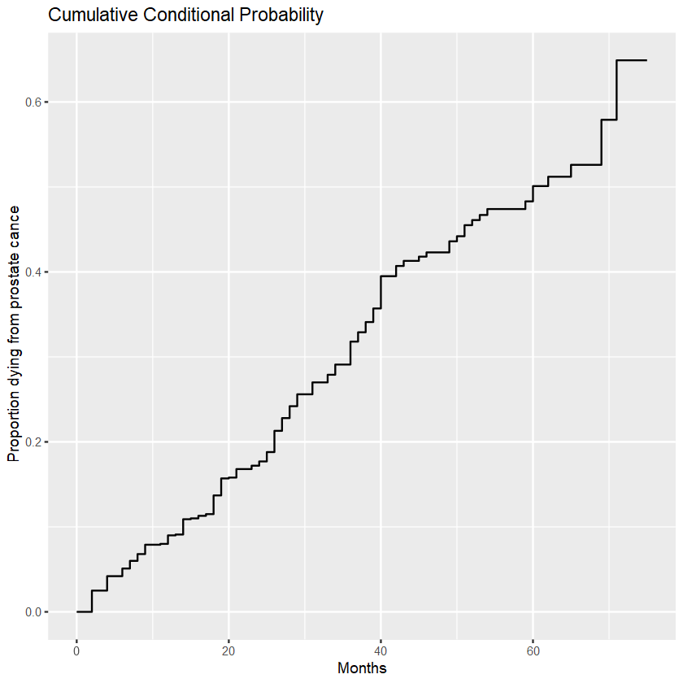

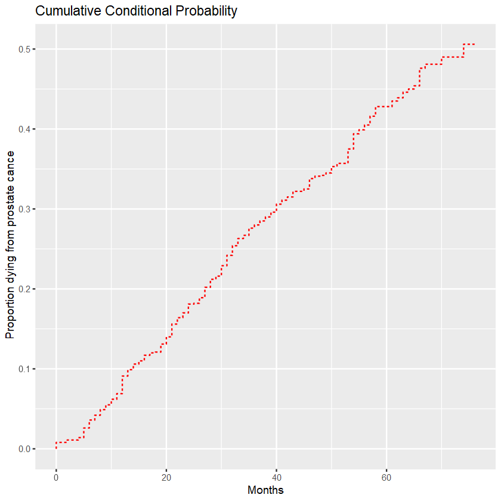

```r
df1 = data2CIC(filter(Byar, Rx == 0), time = "dtime", status = "status2")
df2 = data2CIC(filter(Byar, Rx == 1), time = "dtime", status = "status2")
ggplot(df1, aes(t, CPC)) + geom_step() +
    labs(x = "Months", y = "Proportion dying from prostate cance", title = "Cumulative Conditional Probability")
ggplot(df2, aes(t, CPC)) + geom_step(col = "red", lty = 2) +
    labs(x = "Months", y = "Proportion dying from prostate cance", title = "Cumulative Conditional Probability")
```

#### CPF함수를 이용한 비례오즈모형 적합

#### `cpfpo()` : CPF를 이용한 비례오즈모형 적합

```r
library(Cprob)
```

```r
tis = seq(median(Byar$dtime), max(Byar$dtime), length = 50)
fitcpf = cpfpo(Hist(dtime, status2) ~ Rx + Age + Wt + PF + Hx + Hb + SZ + SG, data = Byar, tis =  tis)
fitcpf
```

```
Test for non-significant effect
                  stat       pvalue
(Intercept) -5.0726529 3.923077e-07
Rx          -2.2300463 2.574437e-02
Age          0.1733980 8.623386e-01
Wt           0.1623687 8.710155e-01
PF           1.6288419 1.033465e-01
Hx          -0.1721601 8.633116e-01
Hb           1.7950573 7.264457e-02
SZ           4.7860989 1.700543e-06
SG           7.8075561 5.773160e-15

 Test for constant fit
                   coef   exp.coef   SE.coef        stat     pvalue
(Intercept) -2.07092574  0.1260690 0.4082530  1.13947763 0.25450400
Rx          -0.87808196  0.4155792 0.3937505  2.28926220 0.02206412
Age          0.05062643  1.0519298 0.2919666  0.09037809 0.92798677
Wt           0.03964381  1.0404401 0.2441591 -0.04195160 0.96653728
PF           0.97618287  2.6543050 0.5993110 -0.58577790 0.55802478
Hx          -0.05750725  0.9441150 0.3340335 -0.14856649 0.88189572
Hb           0.54867478  1.7309576 0.3056586 -2.29418919 0.02177963
SZ           1.95387710  7.0559914 0.4082400  1.15531502 0.24796145
SG           2.80355416 16.5031976 0.3590822 -1.45089637 0.14680872
```

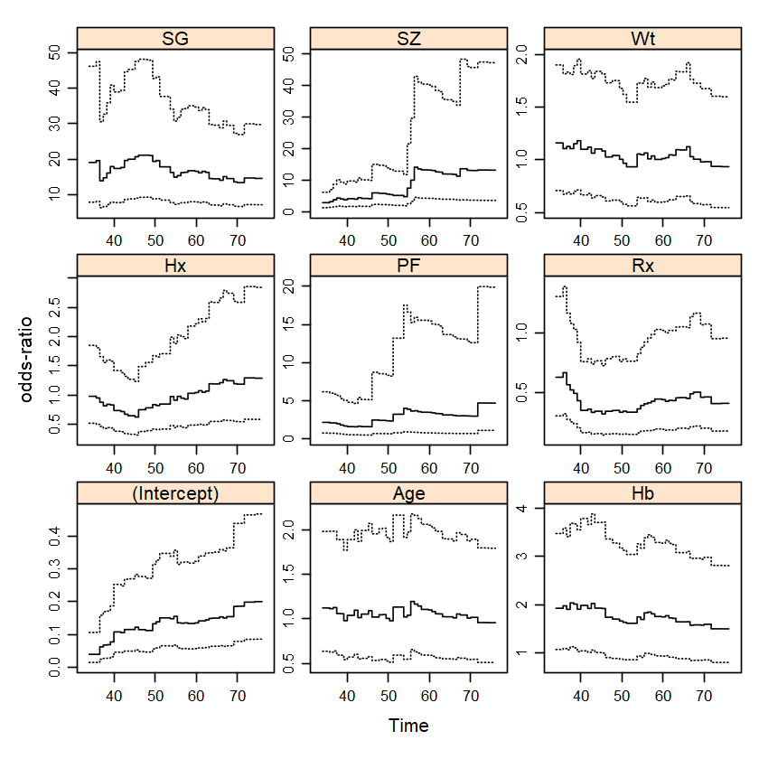

```r
lattice::xyplot(fitcpf, scales = c(relation = "free"))
```